# R Notebook

Imagine 10000 receipts sitting on your table. Each receipt represents a transaction with items that were purchased. The receipt is a representation of stuff that went into a customer’s basket - and therefore ‘Market Basket Analysis’.

That is exactly what the Groceries Data Set contains: a collection of receipts with each line representing 1 receipt and the items purchased. Each line is called a transaction and each column in a row represents an item.

Here is the dataset = GroceryDataSet.csv (comma separated file)

You assignment is to use R to mine the data for association rules. You should report support, confidence and lift and your top 10 rules by lift. Turn in as you would the other problems from HA and KJ. Due 12/12/17 with the packaged set, HW #2.

# Loading the Data

```r
setwd("C:/Users/DaStophe/Documents/GitHub/MSDA---Coursework/Data 624/Homework 11")
df <- read.transactions("GroceryDataSet.csv", sep = ",")
```

> Let’s look at the first 5 transactions to understand how the data is being loaded.

```r
inspect(df[1:5])
```

```
    items
[1] {citrus fruit,margarine,ready soups,semi-finished bread}
[2] {coffee,tropical fruit,yogurt}
[3] {whole milk}
[4] {cream cheese,meat spreads,pip fruit,yogurt}
[5] {condensed milk,long life bakery product,other vegetables,whole milk}
```

> Now we can review common occurences. We see that vgetables and milk are at the top of the list, which is reassuring.

```r
summary(df)
```

```
transactions as itemMatrix in sparse format with
 9835 rows (elements/itemsets/transactions) and
 169 columns (items) and a density of 0.02609146

most frequent items:
      whole milk other vegetables       rolls/buns             soda           yogurt          (Other)
            2513             1903             1809             1715             1372            34055

element (itemset/transaction) length distribution:
sizes
   1    2    3    4    5    6    7    8    9   10   11   12   13   14   15   16   17   18   19   20   21   22
2159 1643 1299 1005  855  645  545  438  350  246  182  117   78   77   55   46   29   14   14    9   11    4
  23   24   26   27   28   29   32
   6    1    1    1    1    3    1

   Min. 1st Qu.  Median    Mean 3rd Qu.    Max.
  1.000   2.000   3.000   4.409   6.000  32.000

includes extended item information - examples:
            labels
1 abrasive cleaner
2 artif. sweetener
3   baby cosmetics
```

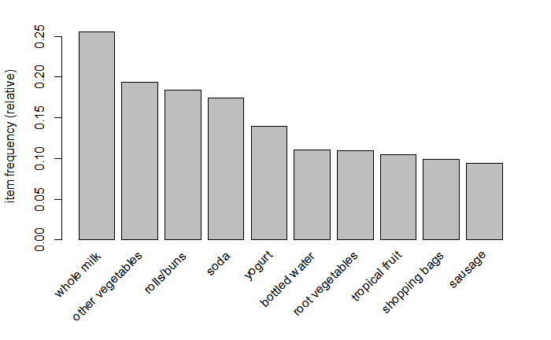

```r
itemFrequencyPlot(df, topN = 10)
```

> Further we can run the apriori function to determine the associated rules. Because we have so many different choices to purchase we will set a lower support. 100 out 9835 gives us a support value of 0.01016777, we will use an arbitrary confidence of .5.

```r
rules <- apriori(df, parameter = list(support = 0.01016777, confidence = 0.5))
```

```
Apriori

Parameter specification:
 confidence minval smax arem  aval originalSupport maxtime    support minlen maxlen target   ext
        0.5    0.1    1 none FALSE            TRUE       5 0.01016777      1     10  rules FALSE

Algorithmic control:
 filter tree heap memopt load sort verbose
    0.1 TRUE TRUE  FALSE TRUE    2    TRUE

Absolute minimum support count: 100

set item appearances ...[0 item(s)] done [0.00s].
set transactions ...[169 item(s), 9835 transaction(s)] done [0.01s].
sorting and recoding items ... [88 item(s)] done [0.01s].
creating transaction tree ... done [0.00s].
checking subsets of size 1 2 3 4 done [0.02s].
writing ... [14 rule(s)] done [0.01s].
creating S4 object  ... done [0.01s].
```

```r
inspect(sort(rules, by = "lift")[1:10])
```

```
     lhs                                 rhs                support    confidence lift     count
[1]  {citrus fruit,root vegetables}   => {other vegetables} 0.01037112 0.5862069  3.029608 102
[2]  {root vegetables,tropical fruit} => {other vegetables} 0.01230300 0.5845411  3.020999 121
[3]  {rolls/buns,root vegetables}     => {other vegetables} 0.01220132 0.5020921  2.594890 120
[4]  {root vegetables,yogurt}         => {other vegetables} 0.01291307 0.5000000  2.584078 127
[5]  {butter,other vegetables}        => {whole milk}       0.01148958 0.5736041  2.244885 113
[6]  {root vegetables,tropical fruit} => {whole milk}       0.01199797 0.5700483  2.230969 118
[7]  {root vegetables,yogurt}         => {whole milk}       0.01453991 0.5629921  2.203354 143
[8]  {domestic eggs,other vegetables} => {whole milk}       0.01230300 0.5525114  2.162336 121
[9]  {whipped/sour cream,yogurt}      => {whole milk}       0.01087951 0.5245098  2.052747 107
[10] {rolls/buns,root vegetables}     => {whole milk}       0.01270971 0.5230126  2.046888 125
```

> Reporting our top rules by lift we see interesting results. It appears that buying vegetables and fruits suggests that similar purchases of other vegetables are possible. We also see those buying butter, eggs, and other animal products are more apt to buy whole milk. The exercise is informative of the power in this type of analysis.